# Data Processing - Japanese

Erin M. Buchanan

Last Update 2024-05-13

## Libraries

```r
library(dplyr)
library(psych)
library(tidyr)
library(ggplot2)
library(rio)
library(RSQLite)
library(tidyverse)
library(jsonlite)
library(janitor)
library(widyr)
library(LexOPS)
library(ggplot2)
```

## Functions

This function is provided by labjs to convert the sqlite files until useable R dataframes for processing.

```r
# from labjs docs
processData <- function(database) {
  con <- dbConnect(
    drv=RSQLite::SQLite(),
    dbname=database
  )

  # Extract main table
  if(con %>% DBI::dbExistsTable("labjs")){
  d <- dbGetQuery(
    conn=con,
    statement='SELECT * FROM labjs'
  )

  # Close connection
  dbDisconnect(
    conn=con
  )

  # Discard connection
  rm(con)

  d.meta <- map_dfr(d$metadata, fromJSON) %>%
    dplyr::rename(
      observation=id
    )

  d <- d %>%
    bind_cols(d.meta) %>%
    select(
      -metadata # Remove metadata column
    )

  # Remove temporary data frame
  rm(d.meta)

  count_unique <- function(x) {
    return(length(unique(x)))
  }

  information_preserved <- function(x, length) {
    return(
      count_unique(str_sub(x, end=i)) ==
        count_unique(x)
    )
  }

  # Figure out the length of the random ids needed
  # to preserve the information therein. (five characters
  # should usually be enougth, but better safe)
  for (i in 5:36) {
    if (
      information_preserved(d$session, i) &&
      information_preserved(d$observation, i)
    ) {
      break()
    }
  }

  d <- d %>%
    dplyr::mutate(
      session=str_sub(session, end=i),
      observation=str_sub(observation, end=i)
    )

  rm(i, count_unique, information_preserved)

  parseJSON <- function(input) {
    return(input %>%
             fromJSON(flatten=T) %>% {
               # Coerce lists
               if (class(.) == 'list') {
                 discard(., is.null) %>%
                   as_tibble()
               } else {
                 .
               } } %>%
             # Sanitize names
             janitor::clean_names() %>%
             # Use only strings for now, and re-encode types later
             mutate_all(as.character)
    )
  }

  d.full <- d %>%
    dplyr::filter(payload == 'full')

  if (nrow(d.full) > 0) {
    d.full %>%
      group_by(observation, id) %>%
      do(
        { map_dfr(.$data, parseJSON) } %>%
          bind_rows()
      ) %>%
      ungroup() %>%
      select(-id) -> d.full
  } else {
    # If there are no full datasets, start from an entirely empty df
    # in order to avoid introducing unwanted columns into the following
    # merge steps.
    d.full <- tibble()
  }

  d %>%
    dplyr::filter(payload %in% c('incremental', 'latest')) %>%
    group_by(observation, id) %>%
    do(
      { map_dfr(.$data, parseJSON) } %>%
        bind_rows()
    ) %>%
    ungroup() %>%
    select(-id) -> d.incremental

  if (nrow(d.full) > 0){

  d.output <- d.full %>%
    bind_rows(
      d.incremental %>% filter(!(observation %in% d.full$observation))
    ) %>%
    type_convert()

  } else {

    d.output <- d.incremental %>% type_convert()

  }

  d.output %>%
    group_by(observation) %>%
    fill(matches('code'), .direction='down') %>%
    fill(matches('code'), .direction='up') %>%
    ungroup() -> d.output

  return(d.output)
  } else {
    DF <- data.frame(url_lab = as.character())
    return(DF)
  }
}
```

## Data Processing Real Data

Import all the data files for that specific language - use the unique() function to eliminate any duplicates from copying the data during the backup process. The data was backed up each week and a “fake” dataset was copied over to have something for the server to write to for practical purposes.

```r
# get all the files
ja_files <- list.files("../../04_Procedure_real",
                       pattern = "*.sqlite",
                       full.names = TRUE,
                       recursive = TRUE)
ja_files <- ja_files[grepl("ja", ja_files)]
ja_info <- file.info(ja_files)
ja_files <- ja_files[ ja_info$size > 1531904]

ja_data <- list()

# open all files
for (i in 1:length(ja_files)){
  ja_data[[i]] <- processData(ja_files[i])
  ja_data[[i]]$url_lab <- as.character(ja_data[[i]]$url_lab)
}

# convert to data frame and make unique
ja_data_all <- bind_rows(ja_data) %>% unique()

nrow(ja_data_all)
```

```
## [1] 2781303
```

```r
# timestamp is somewhat unreliable fix up sender_id
sender_ids <- import("sender_id.csv")
ja_data_all <- ja_data_all %>%
  left_join(sender_ids, by = "sender_id")

nrow(ja_data_all)
```

```
## [1] 2781303
```

### Remove Test Data

Remove all rows that were testers before we officially launched this language.

```r
# remove test data before official start japanese
ja_data_all <- ja_data_all %>%
  filter(timestamp > as.POSIXct("2022-08-28"))

nrow(ja_data_all)
```

```
## [1] 2770025
```

```r
# fix the issue of double displays that happened before 2022-09-01
  # 13_0_98 == 15_0_0
  # 13_0_99 == 15_0_1
  # figure out everyone who saw 15_100 and 15_101 which means extra
  obs_extra <- ja_data_all %>%
    filter(grepl("15_0_100", sender_id)) %>%
    pull(observation) %>%
    unique()
  # remove second instance of trials so 15_0_0* or 15_0_1*
  # be specific because regex coding
  ja_data_all <- ja_data_all %>%
    filter(!(observation %in% obs_extra &
               grepl("15_0_0_0$|15_0_0_1$|15_0_0$|15_0_1_0$|15_0_1_1$|15_0_1$", sender_id)
    ))

nrow(ja_data_all)
```

```
## [1] 2769251
```

### Remove the Participant Information

Here we remove all the columns of unique participant information. Because observation (labjs unique ID code) is not always unique, we bind it with a random subset of our unique code to create no repetitions.

```r
names(ja_data_all)
```

```
##  [1] "observation"                         "sender"
##  [3] "sender_type"                         "sender_id"
##  [5] "uuid"                                "response"
##  [7] "response_action"                     "ended_on"
##  [9] "duration"                            "time_run"
## [11] "time_render"                         "time_show"
## [13] "time_end"                            "time_commit"
## [15] "timestamp"                           "time_switch"
## [17] "url_lab"                             "url_special_code"
## [19] "meta_labjs_version"                  "meta_location"
## [21] "meta_user_agent"                     "meta_platform"
## [23] "meta_language"                       "meta_locale"
## [25] "meta_time_zone"                      "meta_timezone_offset"
## [27] "meta_screen_width"                   "meta_screen_height"
## [29] "meta_scroll_width"                   "meta_scroll_height"
## [31] "meta_window_inner_width"             "meta_window_inner_height"
## [33] "meta_device_pixel_ratio"             "meta_labjs_build_flavor"
## [35] "meta_labjs_build_commit"             "please_tell_us_your_gender"
## [37] "which_year_were_you_born"            "please_tell_us_your_education_level"
## [39] "native_language"                     "dominanthand"
## [41] "x"                                   "word"
## [43] "class"                               "feedback"
## [45] "correct_response"                    "correct"
## [47] "url"                                 "fix_sender"
```

```r
# fill in uuid for each row
ja_data_all <- fill(ja_data_all, uuid, .direction = "down")

# ensure that observation-uuid combination doesn't go awry
temp <- ja_data_all %>%
  group_by(uuid, observation) %>%
  summarize(count = n(), .groups = "keep") %>%
  ungroup() %>%
  mutate(dups_o = duplicated(observation),
         dups_u = duplicated(uuid))

table(temp$dups_o, useNA = "ifany")
```

```
##
## FALSE  TRUE
##  1844     9
```

```r
table(temp$dups_u, useNA = "ifany")
```

```
##
## FALSE  TRUE
##  1845     8
```

```r
ja_data_all$uuid[ja_data_all$observation == "2ec82"] <- "69d2c1ec-7b96-4118-b2ca-e721d930d0aa"
ja_data_all$uuid[ja_data_all$observation == "f83b4"] <- "397f978c-3153-4593-a2a0-7f88e5295b5e"
ja_data_all$uuid[ja_data_all$observation == "32248"] <- "c98e732d-83d7-4abd-9569-4b57760ecea1"
ja_data_all$uuid[ja_data_all$observation == "7f860"] <- "05f101c5-6af7-4223-96db-7de5253ec016"
ja_data_all$uuid[ja_data_all$observation == "ce6ea"] <- "cbebd227-69c7-48fb-b214-ad704990ea98"
ja_data_all$uuid[ja_data_all$observation == "692d0"] <- "e4753908-2f3e-4f70-8e68-f81c657818a0"
ja_data_all$uuid[ja_data_all$observation == "8086b"] <- "7d53c867-d8aa-43f8-8c21-7e2990be1161"

# long timeout merge for consent form
# beginning
# 365b8-38f010df-57ff-477b-8f18-178b75d271b7
# end
# 6dd8c-fdd0f152-faa6-4492-89b9-1e7434c21c2b (this one duped)
ja_data_all$uuid[ja_data_all$uuid == "fdd0f152-faa6-4492-89b9-1e7434c21c2b" & ja_data_all$observation == "6dd8c"] <- "38f010df-57ff-477b-8f18-178b75d271b7"
ja_data_all$observation[ja_data_all$uuid == "38f010df-57ff-477b-8f18-178b75d271b7" & ja_data_all$observation == "6dd8c"] <- "365b8"

ja_data_all$observation <- paste0(ja_data_all$observation, substr(ja_data_all$uuid, 20, 28))

# make sure every row has an id number
sum(is.na(ja_data_all$observation))
```

```
## [1] 0
```

```r
# remove ZPID, mturk, uuid
ja_data_all <- ja_data_all %>%
  select(-url_special_code, -uuid, -meta_location, -x, -url)

ncol(ja_data_all)
```

```
## [1] 43
```

### Write Out Shareable Data

We save the shareable data in compressed format due to large file size. These can be read in with R.

```r
write.csv(ja_data_all,
       gzfile("output_data/full_data/ja_full_data.csv.gz"),
       row.names = F)
```

## Read in Processed Data

If you are reviewing this file for how we processed data, you would start here by importing the shared data file.

```r
ja_data_all <- read.csv("output_data/full_data/ja_full_data.csv.gz")
```

### Original Data Structure

```r
str(ja_data_all)
```

```
## 'data.frame':    2769251 obs. of  43 variables:
##  $ observation                        : chr  "02612bd4d-7d48" "02612bd4d-7d48" "02612bd4d-7d48" "02612bd4d-7d48" ...
##  $ sender                             : chr  "Consent Form" "Demographics Form" "Overall Instructions" "Fixation Cross Practice" ...
##  $ sender_type                        : chr  "html.Screen" "html.Form" "html.Screen" "canvas.Screen" ...
##  $ sender_id                          : chr  "0" "1" "2" "3_0_0_0" ...
##  $ response                           : chr  "continue" NA "continue" NA ...
##  $ response_action                    : chr  "keypress(Space)" NA "keypress(Space)" NA ...
##  $ ended_on                           : chr  "response" "form submission" "response" "timeout" ...
##  $ duration                           : num  23963 22916 7349 500 3000 ...
##  $ time_run                           : num  20964 45036 67972 81257 81752 ...
##  $ time_render                        : num  20951 45017 67950 81252 81750 ...
##  $ time_show                          : num  21067 45051 67984 81267 81767 ...
##  $ time_end                           : num  45031 67966 75332 81750 84750 ...
##  $ time_commit                        : num  45035 67970 75333 81751 84751 ...
##  $ timestamp                          : chr  "2022-09-08 04:24:39.597" "2022-09-08 04:25:02.531" "2022-09-08 04:25:09.895" "2022-09-08 04:25:16.313" ...
```

[output cut: 29 more lines]

## Participant and Experiment Information

In this section, we will put together the demographic data and experiment information data to save as an overall participant information file. This information can be merged with the other data using the `observation` column.

We will mark participants who do not meet our criteria to exclude below:

- Participant did not indicate at least 18 years of age.
- Participant did not complete at least 100 trials.
- Participant did not achieve 80% correct.

We also add information about the length of time within the study, if desired, for filtering, but please note the exclusions later for “too fast” and “too slow” trials.

Next, we add a secondary calculation of percent correct. The research team had a disagreement over percent correct as either: $\frac{n_correct}{n_seen}$ (original calculation that EMB did during the pre-registration) or $\frac{n_correct}{n_answered}$ (secondary discussion that the team *thought* the pre-registration stated). We include both, but used the original way for the calculations because this was the original code *and* it was more conservative (i.e., more people were excluded).

```r
# fix any issues with lab codes
lab_codes <- ja_data_all %>%
  filter(sender == "Consent Form") %>%
  group_by(url_lab) %>%
  summarize(count = n())

lab_codes
```

| url_lab | count |
| --- | --- |
| ZPID | 1845 |

```r
sum(lab_codes$count)
```

```
## [1] 1845
```

```r
##create demographics only data
demos <- ja_data_all %>% #data frame
  filter(sender == "Demographics Form") #filter out only demographics lines

nrow(demos)
```

```
## [1] 1721
```

```r
##create experiment information data
exp <- ja_data_all %>%
  filter(sender == "Consent Form")

nrow(exp)
```

```
## [1] 1845
```

```r
demo_cols <- c("observation", "duration",
             colnames(demos)[grep("^time", colnames(demos))],
             "please_tell_us_your_gender", "which_year_were_you_born",
             "please_tell_us_your_education_level", "native_language")
exp_cols <- c("observation", "duration",
              colnames(exp)[grep("^time", colnames(exp))],
              "url_lab",
              colnames(exp)[grep("meta", colnames(exp))])

participant_DF <- merge(demos[ , demo_cols],
                        exp[ , exp_cols],
                        by = "observation",
                        all = T)

colnames(participant_DF) <- gsub(".x$", "_demographics", colnames(participant_DF))
colnames(participant_DF) <- gsub(".y$", "_consent", colnames(participant_DF))

# look for issues with no consent form
nrow(participant_DF)
```

```
## [1] 1845
```

```r
sum(is.na(participant_DF$timestamp_consent))
```

```
## [1] 0
```

```r
participant_DF$keep_answered <- participant_DF$keep <- "keep"

# only above 18
class(participant_DF$which_year_were_you_born)
```

```
## [1] "integer"
```

```r
participant_DF$keep[(as.numeric(substr(participant_DF$timestamp_consent, 1,4)) - participant_DF$which_year_were_you_born) < 18 | is.na(participant_DF$which_year_were_you_born)] <- "exclude"

participant_DF$keep_answered[(as.numeric(substr(participant_DF$timestamp_consent, 1,4)) - participant_DF$which_year_were_you_born) < 18 | is.na(participant_DF$which_year_were_you_born)] <- "exclude"

table((as.numeric(substr(participant_DF$timestamp_consent, 1,4)) - participant_DF$which_year_were_you_born) < 18, useNA = "ifany")
```

```
##
## FALSE  <NA>
##  1721   124
```

```r
# at least 100 trials + 80%
# in this section, we also merge a representation of the
# time spent in the study in case you wish to use that as
# a filter
number_trials <- ja_data_all %>% #data frame
  filter(sender == "Stimulus Real") %>%  #filter out only the real stimuli
  group_by(observation) %>%
  summarize(n_trials = n(),
            n_correct = sum(correct, na.rm = T),
            p_correct = sum(correct, na.rm = T) / n(),
            n_answered = sum(!is.na(response_action)),
            p_correct_answered = n_correct/n_answered,
            start = min(timestamp),
            end = max(timestamp)) %>%
  mutate(study_length = difftime(end, start, units = "mins"))

number_trials$p_correct_answered[is.na(number_trials$p_correct_answered)] <- 0

# merge with participant data
participant_DF <- merge(participant_DF,
                        number_trials,
                        by = "observation",
                        all = T)

nrow(participant_DF)
```

```
## [1] 1845
```

```r
# mark the people without 100 trials
participant_DF$keep[participant_DF$n_trials < 100 | is.na(participant_DF$n_trials)] <- "exclude"
participant_DF$keep_answered[participant_DF$n_trials < 100 | is.na(participant_DF$n_trials)] <- "exclude"

table(participant_DF$n_trials < 100, useNA = "ifany")
```

```
##
## FALSE  TRUE  <NA>
##  1386    74   385
```

```r
# mark the people who could not get 80% correct
participant_DF$keep[participant_DF$p_correct < .80 | is.na(participant_DF$p_correct)] <- "exclude"
participant_DF$keep_answered[participant_DF$p_correct_answered < .80 | is.na(participant_DF$p_correct_answered)] <- "exclude"

table(participant_DF$p_correct < .80, useNA = "ifany")
```

```
##
## FALSE  TRUE  <NA>
##  1188   272   385
```

```r
table(participant_DF$p_correct_answered < .80, useNA = "ifany")
```

```
##
## FALSE  TRUE  <NA>
##  1280   180   385
```

```r
export(participant_DF, "output_data/participant_data/ja_participant_data.csv", row.names = F)
```

### Exclude Too Young

```r
# find too young
too_young <- na.omit(participant_DF$observation[(as.numeric(substr(participant_DF$timestamp_consent, 1,4)) - participant_DF$which_year_were_you_born) < 18])

# censor out the data
  # keep timestamp consent, url_lab, no keep so code works later
  demo_censor <- colnames(participant_DF)[ -c(1, 20, 22, 39, 40) ]

  all_censor <- colnames(ja_data_all)[ c(6, 8:37, 41:42) ]


participant_DF[ participant_DF$observation %in% too_young ,
                demo_censor] <- NA

nrow(participant_DF)
```

```
## [1] 1845
```

```r
ja_data_all[ ja_data_all$observation %in% too_young ,
             all_censor ] <- NA

nrow(ja_data_all)
```

```
## [1] 2769251
```

```r
# rewrite data
export(participant_DF, "output_data/participant_data/ja_participant_data.csv", row.names = F)

write.csv(ja_data_all,
       gzfile("output_data/full_data/ja_full_data.csv.gz"),
       row.names = F)
```

## Trial Data

Each language will be saved in a separate file with an item specific trial identification number to allow for matching concepts across languages (i.e., cat → katze → gatta).

Participants are expected to incorrectly answer trials; however, they are included in the raw trial level data for this output. Further, computer errors or trials due to missing data (i.e., participant inattentiveness and timeout trials, internet disconnection, computer crashes) are already marked as such in the final data with NA values.

```r
##grab only real trials
real_trials <- ja_data_all %>% #data frame
  filter(sender == "Stimulus Real") %>%  #filter out only the real stimuli
  select(observation, fix_sender, response, response_action, ended_on, duration,
         colnames(ja_data_all)[grep("^time", colnames(ja_data_all))],
         word, class, correct_response, correct)

nrow(real_trials)
```

```
## [1] 890542
```

The response latencies from each participant’s session will be z-scored in line with recommendations from Faust, Balota, Spieler, and Ferraro (1999). We will z-score these *without* the excluded trials:

- Timeout trials (i.e., no response given in 3s window)
- Incorrectly answered trials.
- Response latencies shorter than 160 ms.

Note that it’s ok if we include participants in this file that should be overall excluded, as they will get excluded in the descriptive statistics calculations and before item level results. Basically, everything stays in this file but we mark them for keep or not keep.

```r
# hang on to original time
real_trials$original_duration <- real_trials$duration

# correct overall
table(real_trials$correct, useNA = "ifany")
```

```
##
##  FALSE   TRUE   <NA>
##  75498 779972  35072
```

```r
# exclude due to too short or too long
table(real_trials$duration < 160, useNA = "ifany")
```

```
##
##  FALSE   TRUE
## 873543  16999
```

```r
table(real_trials$duration > 3000, useNA = "ifany")
```

```
##
##  FALSE   TRUE
## 873534  17008
```

```r
# Separate out NA data for the z-score part
# this mostly controls for timeouts
real_trials_NA <- real_trials %>% #data frame
  filter(is.na(correct) | #grab time out trials OR
           correct == FALSE | #grab incorrect trials OR
           duration < 160 | #grab short rts
           duration > 3000) %>%  #grab too long rts
  mutate(Z_RT = NA, #set all Z_RTs to NA for these trials
         duration = NA,
         keep = "exclude")

nrow(real_trials_NA)
```

```
## [1] 119747
```

```r
# this section z-scores the rest of the data
# just not time outs
real_trials_nonNA <-
  real_trials %>% #data frame
  group_by(observation) %>% #group by participant
  filter(!is.na(correct)) %>% #take out the NA timeouts
  filter(correct == TRUE) %>% #only correct trials
  filter(duration >= 160) %>% #longer response latencies
  filter(duration <= 3000) %>% #can't be too long
  mutate(Z_RT = as.vector(scale(duration)), #create a z-score RT
         keep = "keep")

nrow(real_trials_nonNA)
```

```
## [1] 770795
```

```r
# make sure you equally split
nrow(real_trials) == nrow(real_trials_NA) + nrow(real_trials_nonNA)
```

```
## [1] TRUE
```

```r
# put the time outs with the answered trials
real_trials <- bind_rows(real_trials_NA, real_trials_nonNA)

nrow(real_trials)
```

```
## [1] 890542
```

```r
# indicate what participants to exclude
real_trials <- real_trials %>%
  left_join(
    (participant_DF %>% select(observation, keep, keep_answered) %>%
       rename(keep_participant = keep, keep_participant_answered = keep_answered)),
    by = c("observation" = "observation")) %>%
  # sort this so the trial type is right
  arrange(observation, fix_sender)

nrow(real_trials)
```

```
## [1] 890542
```

```r
##write out raw trial data
write.csv(real_trials,
          gzfile("output_data/trial_data/ja_trial_data.csv.gz"),
          row.names = F)
```

## Item Data

The item file will contain lexical information about all stimuli (length, frequency, orthographic neighborhood, bigram frequency). We will merge that information at the end of the study.

The descriptive statistics calculated from the trial level data will then be included: average response latency, average standardized response latency, sample size, standard errors of response latencies, and accuracy rate. The exclusions applied above created `Z_RT` as NA, therefore, they are automatically excluded here as well.

### Using Original Scoring

```r
##read in stimuli data
stimuli_data <- import("../../04_Procedure/ja/ja_words.csv")

# overall numbers of stimuli
nrow(stimuli_data)
```

```
## [1] 5000
```

```r
stimuli_data %>%
  group_by(type, cue_type, target_type) %>%
  summarize(n = n(), .groups = "keep")
```

| type | cue_type | target_type | n |
| --- | --- | --- | --- |
| nonword | nonword | nonword | 1000 |
| nonword | nonword | word | 1000 |
| nonword | word | nonword | 1000 |
| related | word | word | 1000 |
| unrelated | word | word | 1000 |

```r
stimuli_data %>%
  select(target_type, ja_target) %>%
  group_by(target_type) %>%
  unique() %>%
  summarize(n = n())
```

| target_type | n |
| --- | --- |
| nonword | 1000 |
| word | 988 |

```r
stimuli_data %>%
  select(cue_type, ja_cue) %>%
  group_by(cue_type) %>%
  unique() %>%
  summarize(n = n())
```

| cue_type | n |
| --- | --- |
| nonword | 1000 |
| word | 991 |

```r
describeBy(real_trials$Z_RT, group = real_trials$keep) # to ensure we are not calculating any numbers on excluded trials
```

```
##
##  Descriptive statistics by group
## group: exclude
##    vars n mean sd median trimmed mad min  max range skew kurtosis se
## X1    1 0  NaN NA     NA     NaN  NA Inf -Inf  -Inf   NA       NA NA
## ------------------------------------------------------------
## group: keep
##    vars      n mean sd median trimmed  mad   min   max range skew kurtosis se
## X1    1 770793    0  1  -0.26   -0.16 0.59 -4.42 16.47 20.89 2.75    13.04  0
```

```r
describeBy(real_trials$duration, group = real_trials$keep)
```

```
##
##  Descriptive statistics by group
## group: exclude
##    vars n mean sd median trimmed mad min  max range skew kurtosis se
## X1    1 0  NaN NA     NA     NaN  NA Inf -Inf  -Inf   NA       NA NA
## ------------------------------------------------------------
## group: keep
##    vars      n  mean     sd median trimmed    mad min    max  range skew
## X1    1 770795 762.4 317.87 679.31  708.54 180.14 160 2990.8 2830.8 2.47
##    kurtosis   se
## X1     8.73 0.36
```

```r
##create item level data by summarizing
item_data <- real_trials %>% #data frame
  filter(keep_participant == "keep") %>% #participants to keep
  #filter(keep == "keep") %>% #trials to keep
  #note that duration is NA for excluded trials
  #note that Z_RT is NA for excluded trials
  #so the keep is just an extra column
  #need to keep all trials because otherwise accuracy is 100%
  #the keep column includes both timeouts and got it wrongs
  #but probably need to exclude time outs for accuracy
  filter(ended_on == "response") %>%
  group_by(word, class) %>%  #group by word
  dplyr::summarize(avgRT = mean(duration, na.rm = T), #average RT
            avgZ_RT = mean(Z_RT, na.rm = T), #average Z RT
            samplesize = length(na.omit(Z_RT)), #sample size correct
            n_answered = length(Z_RT),
            seRT = sd(duration, na.rm = T)/sqrt(length(na.omit(duration))), #SE RT
            seZ_RT = sd(Z_RT, na.rm = T)/sqrt(length(na.omit(Z_RT))), #SE Z RT
            accuracy = length(na.omit(Z_RT))/length(Z_RT), #accuracy
            .groups = "keep") #word type

# examine words that will get excluded for issues
temp <- item_data %>%
  filter(!(word %in% c(stimuli_data$ja_cue, stimuli_data$ja_target)))

temp
```

| word | class | avgRT | avgZ_RT | samplesize | n_answered | seRT | seZ_RT | accuracy |
| --- | --- | --- | --- | --- | --- | --- | --- | --- |
| 賓図 | nonword | 713.3333 | -0.1196457 | 3 | 3 | 41.07852 | 0.1461475 | 1 |

```r
##remove words that aren't part of the real data (testers)
item_data <- item_data %>%
  filter(word %in% c(stimuli_data$ja_cue, stimuli_data$ja_target))

# number of items run
nrow(item_data)
```

```
## [1] 3942
```

```r
# total number of real items
length(unique(c(stimuli_data$ja_cue, stimuli_data$ja_target)))
```

```
## [1] 3942
```

```r
# what word forms aren't there
setdiff(unique(c(stimuli_data$ja_cue, stimuli_data$ja_target)), item_data$word)
```

```
## character(0)
```

No data will be excluded for being a potential outlier, however, we will recommend cut off criterion for z-score outliers at 2.5 and 3.0 and will calculate these same statistics with those subsets of trials excluded.

```r
##example outlier exclusion for Z > 2.5
##same as above with one extra filter
item_data_2.5 <- real_trials %>%
  filter(abs(Z_RT) < 2.5) %>% #take out trials above 2.5 z scores
  filter(keep_participant == "keep") %>% #participants to keep
  #filter(keep == "keep") %>% #trials to keep
  filter(ended_on == "response") %>%
  group_by(word, class) %>%
  dplyr::summarize(avgRT = mean(duration, na.rm = T),
            avgZ_RT = mean(Z_RT, na.rm = T),
            samplesize = length(na.omit(Z_RT)),
            n_answered = length(Z_RT),
            seRT = sd(duration, na.rm = T)/sqrt(length(na.omit(duration))),
            seZ_RT = sd(Z_RT, na.rm = T)/sqrt(length(na.omit(Z_RT))),
            accuracy = length(na.omit(Z_RT))/length(Z_RT), #accuracy
            .groups = "keep")

##make new column names for these calculations
colnames(item_data_2.5)[-c(1,2)] <- paste("Z2.5_", colnames(item_data_2.5)[-c(1,2)], sep = "")

##example outlier exclusion for Z > 3.0
##same as above with one extra filter
item_data_3.0 <- real_trials %>%
  filter(abs(Z_RT) < 3.0) %>% #take out trials above 3.0 z scores
  filter(keep_participant == "keep") %>% #participants to keep
  #filter(keep == "keep") %>% #trials to keep
  filter(ended_on == "response") %>%
  group_by(word, class) %>%
  dplyr::summarize(avgRT = mean(duration, na.rm = T),
            avgZ_RT = mean(Z_RT, na.rm = T),
            samplesize = length(na.omit(Z_RT)),
            n_answered = length(Z_RT),
            seRT = sd(duration, na.rm = T)/sqrt(length(na.omit(duration))),
            seZ_RT = sd(Z_RT, na.rm = T)/sqrt(length(na.omit(Z_RT))),
            accuracy = length(na.omit(Z_RT))/length(Z_RT), #accuracy
            .groups = "keep")

##make new column names for these calculations
colnames(item_data_3.0)[-c(1,2)] <- paste("Z3.0_", colnames(item_data_3.0)[-c(1,2)], sep = "")

#merge together two z score calculations
item_data_combo <- item_data %>%
  left_join(item_data_2.5,
            by = c("word" = "word", "class" = "class")) %>%
  left_join(item_data_3.0,
            by = c("word" = "word", "class" = "class"))

nrow(item_data_combo)
```

```
## [1] 3942
```

For all real words, the age of acquisition, imageability, concreteness, valence, dominance, arousal, and familiarity values will be indicated because these values do not exist for nonwords. (Example provided from lexops, real data to come after stimuli select set)

```r
##merge with stimuli data
# item_data <- merge(item_data_combo,
#                    lexops,
#                    by.x = "word",
#                    by.y = "string",
#                    all.x = T)

##write out item level data
write.csv(item_data_combo, "output_data/item_data/ja_item_data.csv", row.names = F)
```

### Using Redefined Scoring

```r
##read in stimuli data
stimuli_data <- import("../../04_Procedure/ja/ja_words.csv")

describeBy(real_trials$Z_RT, group = real_trials$keep) # to ensure we are not calculating any numbers on excluded trials
```

```
##
##  Descriptive statistics by group
## group: exclude
##    vars n mean sd median trimmed mad min  max range skew kurtosis se
## X1    1 0  NaN NA     NA     NaN  NA Inf -Inf  -Inf   NA       NA NA
## ------------------------------------------------------------
## group: keep
##    vars      n mean sd median trimmed  mad   min   max range skew kurtosis se
## X1    1 770793    0  1  -0.26   -0.16 0.59 -4.42 16.47 20.89 2.75    13.04  0
```

```r
describeBy(real_trials$duration, group = real_trials$keep)
```

```
##
##  Descriptive statistics by group
## group: exclude
##    vars n mean sd median trimmed mad min  max range skew kurtosis se
## X1    1 0  NaN NA     NA     NaN  NA Inf -Inf  -Inf   NA       NA NA
## ------------------------------------------------------------
## group: keep
##    vars      n  mean     sd median trimmed    mad min    max  range skew
## X1    1 770795 762.4 317.87 679.31  708.54 180.14 160 2990.8 2830.8 2.47
##    kurtosis   se
## X1     8.73 0.36
```

```r
##create item level data by summarizing
item_data <- real_trials %>% #data frame
  filter(keep_participant_answered == "keep") %>% #participants to keep
  #filter(keep == "keep") %>% #trials to keep
  #note that duration is NA for excluded trials
  #note that Z_RT is NA for excluded trials
  #so the keep is just an extra column
  #need to keep all trials because otherwise accuracy is 100%
  #the keep column includes both timeouts and got it wrongs
  #but probably need to exclude time outs for accuracy
  filter(ended_on == "response") %>%
  group_by(word, class) %>%  #group by word
  dplyr::summarize(avgRT = mean(duration, na.rm = T), #average RT
            avgZ_RT = mean(Z_RT, na.rm = T), #average Z RT
            samplesize = length(na.omit(Z_RT)), #sample size correct
            n_answered = length(Z_RT),
            seRT = sd(duration, na.rm = T)/sqrt(length(na.omit(duration))), #SE RT
            seZ_RT = sd(Z_RT, na.rm = T)/sqrt(length(na.omit(Z_RT))), #SE Z RT
            accuracy = length(na.omit(Z_RT))/length(Z_RT), #accuracy
            .groups = "keep") #word type

##remove words that aren't part of the real data (testers)
item_data <- item_data %>%
  filter(word %in% c(stimuli_data$ja_cue, stimuli_data$ja_target))

nrow(item_data)
```

```
## [1] 3942
```

```r
length(unique(c(stimuli_data$ja_cue, stimuli_data$ja_target)))
```

```
## [1] 3942
```

```r
##example outlier exclusion for Z > 2.5
##same as above with one extra filter
item_data_2.5 <- real_trials %>%
  filter(abs(Z_RT) < 2.5) %>% #take out trials above 2.5 z scores
  filter(keep_participant_answered == "keep") %>% #participants to keep
  #filter(keep == "keep") %>% #trials to keep
  filter(ended_on == "response") %>%
  group_by(word, class) %>%
  dplyr::summarize(avgRT = mean(duration, na.rm = T),
            avgZ_RT = mean(Z_RT, na.rm = T),
            samplesize = length(na.omit(Z_RT)),
            n_answered = length(Z_RT),
            seRT = sd(duration, na.rm = T)/sqrt(length(na.omit(duration))),
            seZ_RT = sd(Z_RT, na.rm = T)/sqrt(length(na.omit(Z_RT))),
            accuracy = length(na.omit(Z_RT))/length(Z_RT), #accuracy
            .groups = "keep")

##make new column names for these calculations
colnames(item_data_2.5)[-c(1,2)] <- paste("Z2.5_", colnames(item_data_2.5)[-c(1,2)], sep = "")

##example outlier exclusion for Z > 3.0
##same as above with one extra filter
item_data_3.0 <- real_trials %>%
  filter(abs(Z_RT) < 3.0) %>% #take out trials above 3.0 z scores
  filter(keep_participant_answered == "keep") %>% #participants to keep
  #filter(keep == "keep") %>% #trials to keep
  filter(ended_on == "response") %>%
  group_by(word, class) %>%
  dplyr::summarize(avgRT = mean(duration, na.rm = T),
            avgZ_RT = mean(Z_RT, na.rm = T),
            samplesize = length(na.omit(Z_RT)),
            n_answered = length(Z_RT),
            seRT = sd(duration, na.rm = T)/sqrt(length(na.omit(duration))),
            seZ_RT = sd(Z_RT, na.rm = T)/sqrt(length(na.omit(Z_RT))),
            accuracy = length(na.omit(Z_RT))/length(Z_RT), #accuracy
            .groups = "keep")

##make new column names for these calculations
colnames(item_data_3.0)[-c(1,2)] <- paste("Z3.0_", colnames(item_data_3.0)[-c(1,2)], sep = "")

#merge together two z score calculations
item_data_combo <- item_data %>%
  left_join(item_data_2.5,
            by = c("word" = "word", "class" = "class")) %>%
  left_join(item_data_3.0,
            by = c("word" = "word", "class" = "class"))

nrow(item_data_combo)
```

```
## [1] 3942
```

```r
##merge with stimuli data
# item_data <- merge(item_data_combo,
#                    lexops,
#                    by.x = "word",
#                    by.y = "string",
#                    all.x = T)

##write out item level data
write.csv(item_data_combo, "output_data/item_data/ja_answered_item_data.csv", row.names = F)
```

## Priming Data

- 5/20: fixed the following issues that were misaligned

```r
# line up trials for some mismatches
real_trials <- real_trials %>%
  filter(!(observation == "692d08e68-f81c" & fix_sender == "05_00_044_1")) %>%
  filter(!(observation == "7f86096db-7de5" & fix_sender == "15_00_093_1")) %>%
  filter(!(observation == "8086b8c21-7e29" & fix_sender == "17_00_075_1"))
```

### Using Original Scoring

Priming is defined as the subtraction of average z-scored related response latency for an item from the corresponding item in the unrelated condition. Also, we’ve included the calculation for non-scaled data, but the z-score calculation is recommended.

```r
# figure out trial type ----
  # only select only a few columns
  priming_trials <- real_trials %>%
  # note that we don't exclude trials here because we need to keep
  # them in order to pair together cue-target
  # they will excluded in a minute
    select(observation, duration, word, class, correct,
           Z_RT, fix_sender, timestamp, keep, keep_participant,
           keep_participant_answered, ended_on, original_duration) %>%
    arrange(observation, fix_sender)
  # add trial code and if it's cue/target
  priming_trials$trial_code <- NA
  priming_trials$which <- NA
  # add that information
  for (person in unique(priming_trials$observation)){

    priming_trials$trial_code[priming_trials$observation == person] <-
      rep(1:401, each = 2, length.out = length(priming_trials$trial_code[priming_trials$observation == person]))

    priming_trials$which[priming_trials$observation == person] <-
      rep(c("cue", "target"), times = 2,
          length.out = length(priming_trials$trial_code[priming_trials$observation == person]))

  }

  nrow(priming_trials)
```

```
## [1] 890539
```

```r
  # pivot wider with information you need
  priming_trials$unique_trial <- paste(priming_trials$observation,
                                        priming_trials$trial_code, sep = "_")
  # do it with merge because ugh pivot
  priming_wide <- merge(
    priming_trials[priming_trials$which == "cue" , ], #just cues
    priming_trials[priming_trials$which == "target" , ], #just targets
    by = "unique_trial",
    all = T
  )
  # take just what we need
  priming_wide <- priming_wide[ , c("unique_trial", "observation.x", "word.x",
                                  "class.x", "correct.x", "trial_code.x",
                                  "duration.y", "word.y", "class.y", "correct.y",
                                  "Z_RT.y", "keep.y", "keep_participant.y",
                                  "keep_participant_answered.y",
                                  "ended_on.x", "ended_on.y",
                                  "original_duration.y")]

  # good names
  colnames(priming_wide) <- c("unique_trial", "observation", "cue_word",
                            "cue_type", "cue_correct", "trial_order",
                            "target_duration", "target_word", "target_type",
                            "target_correct", "target_Z_RT",
                            "keep_target", "keep_participant",
                            "keep_participant_answered",
                            "cue_end_of_trial", "target_end_of_trial",
                            "target_original_duration")

  nrow(priming_wide)
```

```
## [1] 445335
```

```r
  temp <-
    priming_wide %>%
    group_by(observation, cue_type, target_type) %>%
    summarize(trial_n = n(),
              .groups = "keep") %>%
    filter(!is.na(target_type)) %>%
    left_join(priming_wide %>%
                group_by(observation) %>%
                summarize(person_n = n(),
                          .groups = "keep"),
              by = "observation") %>%
    # filter(person_n > 49) %>%
    mutate(prop_n = trial_n / person_n) %>%
    group_by(cue_type, target_type) %>%
    summarize(overall_prop = mean(prop_n),
              .groups = "keep")

  temp
```

| cue_type | target_type | overall_prop |
| --- | --- | --- |
| nonword | nonword | 0.3782457 |
| nonword | word | 0.1251556 |
| word | nonword | 0.1252189 |
| word | word | 0.3738179 |

```r
  # only focus on related-unrelated
  priming_focus <- subset(priming_wide, target_type == "word" & cue_type == "word")
  priming_focus$word_combo <- paste0(priming_focus$cue_word, priming_focus$target_word)

  # add if it's related or unrelated
  stimuli_data$word_combo <- paste0(stimuli_data$ja_cue, stimuli_data$ja_target)
  priming_focus <- merge(priming_focus, stimuli_data[ , c("type", "word_combo")],
                    by = "word_combo", all.x = T)

  # check for issues
  temp <- priming_focus %>%
    filter(is.na(type))
  nrow(temp)
```

```
## [1] 0
```

```r
  # subset out NAs at some point they will be practice trials
  priming_focus <- subset(priming_focus, !is.na(type))

  nrow(priming_focus)
```

```
## [1] 166730
```

```r
  table(priming_focus$type, useNA = "ifany")
```

```
##
##   related unrelated
##     83377     83353
```

```r
  export(priming_focus, "output_data/priming_data/ja_prime_trials.csv", row.names = F)

  temp <- priming_focus %>%
    group_by(observation, type) %>%
    summarize(person_n = n(), .groups = "keep") %>%
    left_join(
      priming_focus %>%
        group_by(observation) %>%
        summarize(total_n = n(), .groups = "keep"),
      by = "observation"
    ) %>%
    mutate(overall_prop = person_n / total_n) %>%
    group_by(type) %>%
    summarize(mean_prop = mean(overall_prop), .groups = "keep")

  temp
```

| type | mean_prop |
| --- | --- |
| related | 0.5005819 |
| unrelated | 0.5018356 |

```r
  # calculate the total N versus timeout N
  ja_num_trials <- priming_focus %>%
    group_by(word_combo) %>%
    summarize(
              # target_correct = sum(target_correct, na.rm = T),
              target_answeredN = sum(target_end_of_trial == "response", na.rm = T),
              target_timeoutN = sum(target_end_of_trial == "timeout", na.rm = T),
              # target_prop_correct = target_correct/target_answeredN,
              # cue_correct = sum(cue_correct, na.rm = T),
              cue_answeredN = sum(cue_end_of_trial == "response", na.rm = T),
              cue_timeoutN = sum(cue_end_of_trial == "timeout", na.rm = T),
              # cue_prop_correct = cue_correct/cue_answeredN
              )

  ja_num_trials2 <-
    priming_focus %>%
    filter(keep_participant == "keep") %>%  # keep the participant
    group_by(word_combo) %>%
    summarize(target_correct_keep = sum(target_correct, na.rm = T),
              target_answeredN_keep = sum(target_end_of_trial == "response", na.rm = T),
              target_timeoutN_keep = sum(target_end_of_trial == "timeout", na.rm = T),
              target_prop_correct_keep = target_correct_keep/target_answeredN_keep,
              cue_correct_keep = sum(cue_correct, na.rm = T),
              cue_answeredN_keep = sum(cue_end_of_trial == "response", na.rm = T),
              cue_timeoutN_keep = sum(cue_end_of_trial == "timeout", na.rm = T),
              cue_prop_correct_keep = cue_correct_keep/cue_answeredN_keep)

  ja_num_trials <- ja_num_trials %>%
    full_join(ja_num_trials2)

  # subset out NAs they are test / practice trials
  # only correct answers and trials to keep
  priming_Z <- priming_focus %>%
    filter(!is.na(type)) %>%
    filter(keep_target == "keep") %>% # to exclude correct trials too short
    filter(target_correct == TRUE) %>% # to make sure only correct trials
    filter(keep_participant == "keep") # participants to keep

  nrow(priming_Z)
```

```
## [1] 135656
```

```r
  table(priming_Z$type, useNA = "ifany")
```

```
##
##   related unrelated
##     68193     67463
```

```r
# Calculate Statistics ----------------------------------------------------

  priming_Z_summary <- priming_Z %>%
  ##group them by target word and condition related/unrelated
  group_by(word_combo, type, target_word) %>%
  ##create average scores by condition
  dplyr::summarize(avgRT = mean(target_duration, na.rm = T),
            avgZ_RT = mean(target_Z_RT, na.rm = T),
            target_sample_keep = length(na.omit(target_Z_RT)),
            seRT = sd(target_duration, na.rm = T)/sqrt(length(na.omit(target_duration))),
            seZ_RT = sd(target_Z_RT, na.rm = T)/sqrt(length(na.omit(target_Z_RT))),
            .groups = "keep") %>%
    # merge with the number of trials data
    left_join(ja_num_trials, by = c("word_combo" = "word_combo")) %>%
    # deal with duplicates because of translation
    arrange(target_word, type) %>%
      group_by(type) %>%
      mutate(target_word_unique = make.unique(target_word)) %>%
    ungroup() %>%
      # filter(type == "related") %>%
      # select(word_combo, target_word_unique) %>%
      # export(., file = "../../03_Materials/matched_stimuli/ja_trial_unique.csv")

    ##spread that into wide format so we can subtract
  pivot_wider(names_from = "type",
              id_cols = "target_word_unique",
              values_from = c("avgRT", "avgZ_RT",
                              "seRT", "seZ_RT",
                              # "target_correct",
                              "target_answeredN",
                              "target_timeoutN",
                              # "target_prop_correct",
                              "target_correct_keep",
                              "target_answeredN_keep",
                              "target_timeoutN_keep",
                              "target_prop_correct_keep",
                              # "cue_correct",
                              "cue_answeredN",
                              "cue_timeoutN",
                              # "cue_prop_correct",
                              "cue_correct_keep",
                              "cue_answeredN_keep",
                              "cue_timeoutN_keep",
                              "cue_prop_correct_keep",
                              "target_sample_keep"
                              )) %>%
  ##create the priming scores by subtracting unrelated - related for that target word only
  mutate(avgRT_prime = avgRT_unrelated - avgRT_related) %>%
  mutate(avgZ_prime = avgZ_RT_unrelated - avgZ_RT_related)

  nrow(priming_Z_summary)
```

```
## [1] 1000
```

```r
## this process will be repeated for 2.5 and 3.0 z score outliers excluded
  priming_Z_summary_no2.5 <- priming_Z %>%
  ##filter out z score outliers
  filter(target_Z_RT < 2.50) %>%
  ##group them by target word and condition related/unrelated
  group_by(word_combo, type, target_word) %>%
  ##create average scores by condition
  dplyr::summarize(avgRT = mean(target_duration, na.rm = T),
            avgZ_RT = mean(target_Z_RT, na.rm = T),
            target_sample_keep = length(na.omit(target_Z_RT)),
            seRT = sd(target_duration, na.rm = T)/sqrt(length(na.omit(target_duration))),
            seZ_RT = sd(target_Z_RT, na.rm = T)/sqrt(length(na.omit(target_Z_RT))),
            .groups = "keep") %>%
    # deal with duplicates because of translation
    arrange(target_word, type) %>%
      group_by(type) %>%
      mutate(target_word_unique = make.unique(target_word)) %>%
    ungroup() %>%
  ##spread that into wide format so we can subtract
  pivot_wider(names_from = "type",
              id_cols = "target_word_unique",
              values_from = c("avgRT", "avgZ_RT", "seRT", "seZ_RT",
                              "target_sample_keep")) %>%
  ##create the priming scores by subtracting unrelated - related for that target word only
  mutate(avgRT_prime = avgRT_unrelated - avgRT_related) %>%
  mutate(avgZ_prime = avgZ_RT_unrelated - avgZ_RT_related)

  priming_Z_summary_no3.0 <- priming_Z %>%
  ##filter out z score outliers
  filter(target_Z_RT < 3.0) %>%
  ##group them by target word and condition related/unrelated
  group_by(word_combo, type, target_word) %>%
  ##create average scores by condition
  dplyr::summarize(avgRT = mean(target_duration, na.rm = T),
            avgZ_RT = mean(target_Z_RT, na.rm = T),
            target_sample_keep = length(na.omit(target_Z_RT)),
            seRT = sd(target_duration, na.rm = T)/sqrt(length(na.omit(target_duration))),
            seZ_RT = sd(target_Z_RT, na.rm = T)/sqrt(length(na.omit(target_Z_RT))),
            .groups = "keep") %>%
    # merge with the number of trials data
    left_join(ja_num_trials, by = c("word_combo" = "word_combo")) %>%
    # deal with duplicates because of translation
    arrange(target_word, type) %>%
      group_by(type) %>%
      mutate(target_word_unique = make.unique(target_word)) %>%
    ungroup() %>%
  ##spread that into wide format so we can subtract
  pivot_wider(names_from = "type",
              id_cols = "target_word_unique",
              values_from = c("avgRT", "avgZ_RT", "seRT", "seZ_RT",
                              "target_sample_keep")) %>%
  ##create the priming scores by subtracting unrelated - related for that target word only
  mutate(avgRT_prime = avgRT_unrelated - avgRT_related) %>%
  mutate(avgZ_prime = avgZ_RT_unrelated - avgZ_RT_related)
```

Here we make a quick plot to ensure nothing super weird is happening with the distribution of the data.

```r
combo <- bind_rows(
  priming_Z_summary %>% mutate(where = "priming"),
  priming_Z_summary_no2.5 %>% mutate(where = "priming2.5"),
  priming_Z_summary_no3.0 %>% mutate(where = "priming3.0")
)

nrow(combo) / 3
```

```
## [1] 1000
```

```r
tapply(combo$avgZ_prime, combo$where, mean, na.rm = T)
```

```
##    priming priming2.5 priming3.0
##  0.1480938  0.1236537  0.1281614
```

```r
tapply(combo$avgZ_prime, combo$where, sd, na.rm = T)
```

```
##    priming priming2.5 priming3.0
##  0.2753537  0.2186787  0.2273340
```

```r
tapply(combo$avgZ_prime, combo$where, function(x){sd(x, na.rm = T)/sqrt(length(!is.na(x)))})
```

```
##     priming  priming2.5  priming3.0
## 0.008707450 0.006915227 0.007188932
```

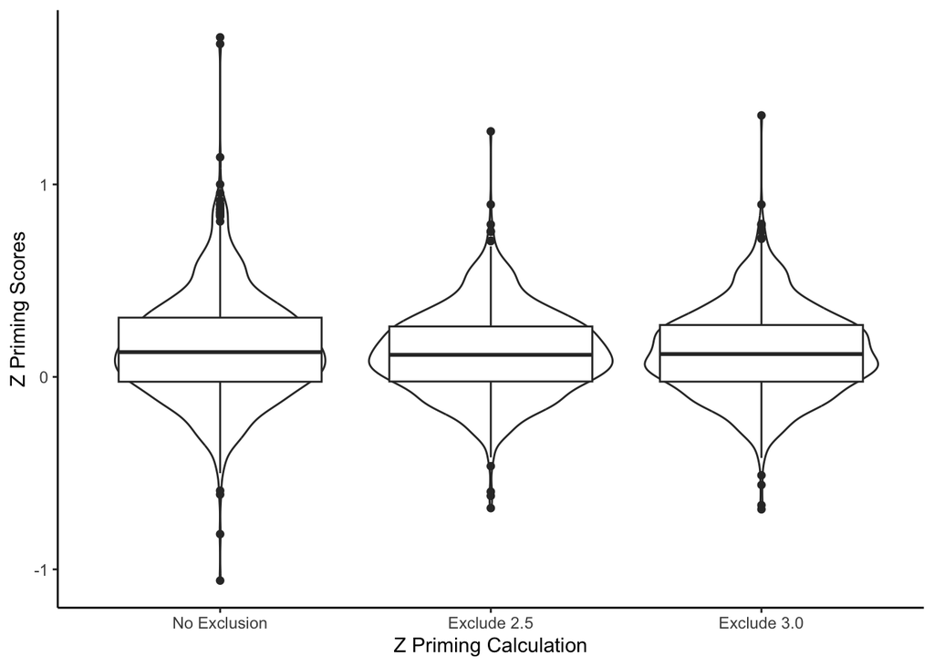

```r
ggplot(combo, aes(where, avgZ_prime)) +
  geom_violin() +
  geom_boxplot() +
  theme_classic() +
  ylab("Z Priming Scores") +
  xlab("Z Priming Calculation") +
  scale_x_discrete(labels = c("No Exclusion", "Exclude 2.5", "Exclude 3.0"))
```

### Write out Original Scores

The similarity scores calculated during stimuli selection will be included, as well as other popular measures of similarity if they are available in that language.

```r
##merge target information with the similarity scores
## -- to be added after calculation for final pairs --

##write out the priming data
write.csv(priming_Z_summary, "output_data/priming_data/ja_prime_summary.csv", row.names = F)
write.csv(priming_Z_summary_no2.5, "output_data/priming_data/ja_prime_summary_no2.5.csv", row.names = F)
write.csv(priming_Z_summary_no3.0, "output_data/priming_data/ja_prime_summary_no3.0.csv", row.names = F)
```

### Using Redefined Accuracy

```r
# figure out trial type ----
  # only select only a few columns
  priming_trials <- real_trials %>%
  # note that we don't exclude trials here because we need to keep
  # them in order to pair together cue-target
  # they will excluded in a minute
    select(observation, duration, word, class, correct,
           Z_RT, fix_sender, timestamp, keep, keep_participant,
           keep_participant_answered, ended_on, original_duration) %>%
    arrange(observation, fix_sender)
  # add trial code and if it's cue/target
  priming_trials$trial_code <- NA
  priming_trials$which <- NA
  # add that information
  for (person in unique(priming_trials$observation)){

    priming_trials$trial_code[priming_trials$observation == person] <-
      rep(1:401, each = 2, length.out = length(priming_trials$trial_code[priming_trials$observation == person]))

    priming_trials$which[priming_trials$observation == person] <-
      rep(c("cue", "target"), times = 2,
          length.out = length(priming_trials$trial_code[priming_trials$observation == person]))

  }

  # pivot wider with information you need
  priming_trials$unique_trial <- paste(priming_trials$observation,
                                        priming_trials$trial_code, sep = "_")
  # do it with merge because ugh pivot
  priming_wide <- merge(
    priming_trials[priming_trials$which == "cue" , ], #just cues
    priming_trials[priming_trials$which == "target" , ], #just targets
    by = "unique_trial",
    all = T
  )
  # take just what we need
  priming_wide <- priming_wide[ , c("unique_trial", "observation.x", "word.x",
                                  "class.x", "correct.x", "trial_code.x",
                                  "duration.y", "word.y", "class.y", "correct.y",
                                  "Z_RT.y", "keep.y", "keep_participant.y",
                                  "keep_participant_answered.y",
                                  "ended_on.x", "ended_on.y",
                                  "original_duration.y")]

  # good names
  colnames(priming_wide) <- c("unique_trial", "observation", "cue_word",
                            "cue_type", "cue_correct", "trial_order",
                            "target_duration", "target_word", "target_type",
                            "target_correct", "target_Z_RT",
                            "keep_target", "keep_participant",
                            "keep_participant_answered",
                            "cue_end_of_trial", "target_end_of_trial",
                            "target_original_duration")

  # only focus on related-unrelated
  priming_focus <- subset(priming_wide, target_type == "word" & cue_type == "word")
  priming_focus$word_combo <- paste0(priming_focus$cue_word, priming_focus$target_word)

  # add if it's related or unrelated
  stimuli_data$word_combo <- paste0(stimuli_data$ja_cue, stimuli_data$ja_target)
  priming_focus <- merge(priming_focus, stimuli_data[ , c("type", "word_combo")],
                    by = "word_combo", all.x = T)

  # subset out NAs at some point they will be practice trials
  priming_focus <- subset(priming_focus, !is.na(type))

  export(priming_focus, "output_data/priming_data/ja_answered_prime_trials.csv", row.names = F)

  # calculate the total N versus timeout N
  ja_num_trials <- priming_focus %>%
    group_by(word_combo) %>%
    summarize(
              # target_correct = sum(target_correct, na.rm = T),
              target_answeredN = sum(target_end_of_trial == "response", na.rm = T),
              target_timeoutN = sum(target_end_of_trial == "timeout", na.rm = T),
              # target_prop_correct = target_correct/target_answeredN,
              # cue_correct = sum(cue_correct, na.rm = T),
              cue_answeredN = sum(cue_end_of_trial == "response", na.rm = T),
              cue_timeoutN = sum(cue_end_of_trial == "timeout", na.rm = T),
              # cue_prop_correct = cue_correct/cue_answeredN
              )

  ja_num_trials2 <-
    priming_focus %>%
    filter(keep_participant_answered == "keep") %>%  # keep the participant
    group_by(word_combo) %>%
    summarize(target_correct_keep = sum(target_correct, na.rm = T),
              target_answeredN_keep = sum(target_end_of_trial == "response", na.rm = T),
              target_timeoutN_keep = sum(target_end_of_trial == "timeout", na.rm = T),
              target_prop_correct_keep = target_correct_keep/target_answeredN_keep,
              cue_correct_keep = sum(cue_correct, na.rm = T),
              cue_answeredN_keep = sum(cue_end_of_trial == "response", na.rm = T),
              cue_timeoutN_keep = sum(cue_end_of_trial == "timeout", na.rm = T),
              cue_prop_correct_keep = cue_correct_keep/cue_answeredN_keep)

  ja_num_trials <- ja_num_trials %>%
    full_join(ja_num_trials2)

  # subset out NAs they are test / practice trials
  # only correct answers and trials to keep
  priming_Z <- priming_focus %>%
    filter(!is.na(type)) %>%
    filter(keep_target == "keep") %>% # to exclude correct trials too short
    filter(target_correct == TRUE) %>% # to make sure only correct trials
    filter(keep_participant_answered == "keep") # participants to keep

  nrow(priming_Z)
```

```
## [1] 141267
```

```r
  table(priming_Z$type, useNA = "ifany")
```

```
##
##   related unrelated
##     70997     70270
```

```r
# Calculate Statistics ----------------------------------------------------

  priming_Z_summary <- priming_Z %>%
  ##group them by target word and condition related/unrelated
  group_by(word_combo, type, target_word) %>%
  ##create average scores by condition
  dplyr::summarize(avgRT = mean(target_duration, na.rm = T),
            avgZ_RT = mean(target_Z_RT, na.rm = T),
            target_sample_keep = length(na.omit(target_Z_RT)),
            seRT = sd(target_duration, na.rm = T)/sqrt(length(na.omit(target_duration))),
            seZ_RT = sd(target_Z_RT, na.rm = T)/sqrt(length(na.omit(target_Z_RT))),
            .groups = "keep") %>%
    # merge with the number of trials data
    left_join(ja_num_trials, by = c("word_combo" = "word_combo")) %>%
    # deal with duplicates because of translation
    arrange(target_word, type) %>%
      group_by(type) %>%
      mutate(target_word_unique = make.unique(target_word)) %>%
    ungroup() %>%
    ##spread that into wide format so we can subtract
  pivot_wider(names_from = "type",
              id_cols = "target_word_unique",
              values_from = c("avgRT", "avgZ_RT",
                              "seRT", "seZ_RT",
                              # "target_correct",
                              "target_answeredN",
                              "target_timeoutN",
                              # "target_prop_correct",
                              "target_correct_keep",
                              "target_answeredN_keep",
                              "target_timeoutN_keep",
                              "target_prop_correct_keep",
                              # "cue_correct",
                              "cue_answeredN",
                              "cue_timeoutN",
                              # "cue_prop_correct",
                              "cue_correct_keep",
                              "cue_answeredN_keep",
                              "cue_timeoutN_keep",
                              "cue_prop_correct_keep",
                              "target_sample_keep"
                              )) %>%
  ##create the priming scores by subtracting unrelated - related for that target word only
  mutate(avgRT_prime = avgRT_unrelated - avgRT_related) %>%
  mutate(avgZ_prime = avgZ_RT_unrelated - avgZ_RT_related)

  nrow(priming_Z_summary)
```

```
## [1] 1000
```

```r
## this process will be repeated for 2.5 and 3.0 z score outliers excluded
  priming_Z_summary_no2.5 <- priming_Z %>%
  ##filter out z score outliers
  filter(target_Z_RT < 2.50) %>%
  ##group them by target word and condition related/unrelated
  group_by(word_combo, type, target_word) %>%
  ##create average scores by condition
  dplyr::summarize(avgRT = mean(target_duration, na.rm = T),
            avgZ_RT = mean(target_Z_RT, na.rm = T),
            target_sample_keep = length(na.omit(target_Z_RT)),
            seRT = sd(target_duration, na.rm = T)/sqrt(length(na.omit(target_duration))),
            seZ_RT = sd(target_Z_RT, na.rm = T)/sqrt(length(na.omit(target_Z_RT))),
            .groups = "keep") %>%
    # deal with duplicates because of translation
    arrange(target_word, type) %>%
      group_by(type) %>%
      mutate(target_word_unique = make.unique(target_word)) %>%
    ungroup() %>%
  ##spread that into wide format so we can subtract
  pivot_wider(names_from = "type",
              id_cols = "target_word_unique",
              values_from = c("avgRT", "avgZ_RT", "seRT", "seZ_RT",
                              "target_sample_keep")) %>%
  ##create the priming scores by subtracting unrelated - related for that target word only
  mutate(avgRT_prime = avgRT_unrelated - avgRT_related) %>%
  mutate(avgZ_prime = avgZ_RT_unrelated - avgZ_RT_related)

  priming_Z_summary_no3.0 <- priming_Z %>%
  ##filter out z score outliers
  filter(target_Z_RT < 3.0) %>%
  ##group them by target word and condition related/unrelated
  group_by(word_combo, type, target_word) %>%
  ##create average scores by condition
  dplyr::summarize(avgRT = mean(target_duration, na.rm = T),
            avgZ_RT = mean(target_Z_RT, na.rm = T),
            target_sample_keep = length(na.omit(target_Z_RT)),
            seRT = sd(target_duration, na.rm = T)/sqrt(length(na.omit(target_duration))),
            seZ_RT = sd(target_Z_RT, na.rm = T)/sqrt(length(na.omit(target_Z_RT))),
            .groups = "keep") %>%
    # merge with the number of trials data
    left_join(ja_num_trials, by = c("word_combo" = "word_combo")) %>%
    # deal with duplicates because of translation
    arrange(target_word, type) %>%
      group_by(type) %>%
      mutate(target_word_unique = make.unique(target_word)) %>%
    ungroup() %>%
  ##spread that into wide format so we can subtract
  pivot_wider(names_from = "type",
              id_cols = "target_word_unique",
              values_from = c("avgRT", "avgZ_RT", "seRT", "seZ_RT",
                              "target_sample_keep")) %>%
  ##create the priming scores by subtracting unrelated - related for that target word only
  mutate(avgRT_prime = avgRT_unrelated - avgRT_related) %>%
  mutate(avgZ_prime = avgZ_RT_unrelated - avgZ_RT_related)
```

```r
combo <- bind_rows(
  priming_Z_summary %>% mutate(where = "priming"),
  priming_Z_summary_no2.5 %>% mutate(where = "priming2.5"),
  priming_Z_summary_no3.0 %>% mutate(where = "priming3.0")
)

nrow(combo) / 3
```

```
## [1] 1000
```

```r
tapply(combo$avgZ_prime, combo$where, mean, na.rm = T)
```

```
##    priming priming2.5 priming3.0
##  0.1468331  0.1232355  0.1277698
```

```r
tapply(combo$avgZ_prime, combo$where, sd, na.rm = T)
```

```
##    priming priming2.5 priming3.0
##  0.2735088  0.2169913  0.2260375
```

```r
tapply(combo$avgZ_prime, combo$where, function(x){sd(x, na.rm = T)/sqrt(length(!is.na(x)))})
```

```
##     priming  priming2.5  priming3.0
## 0.008649109 0.006861868 0.007147935
```

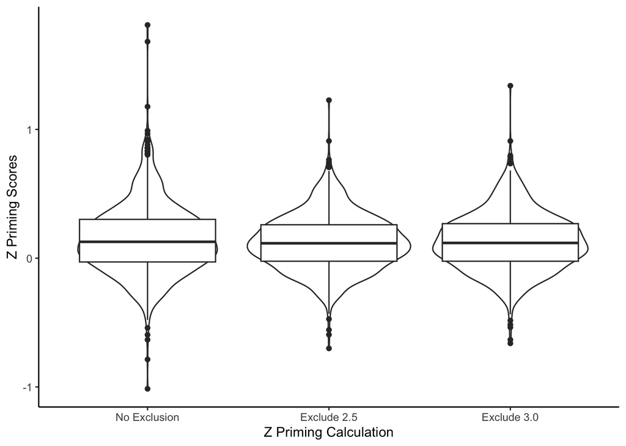

```r
ggplot(combo, aes(where, avgZ_prime)) +
  geom_violin() +
  geom_boxplot() +
  theme_classic() +
  ylab("Z Priming Scores") +
  xlab("Z Priming Calculation") +
  scale_x_discrete(labels = c("No Exclusion", "Exclude 2.5", "Exclude 3.0"))
```

### Write out Recalculated Scores

The similarity scores calculated during stimuli selection will be included, as well as other popular measures of similarity if they are available in that language.

```r
##merge target information with the similarity scores
## -- to be added after calculation for final pairs --

##write out the priming data
write.csv(priming_Z_summary, "output_data/priming_data/ja_answered_prime_summary.csv", row.names = F)
write.csv(priming_Z_summary_no2.5, "output_data/priming_data/ja_answered_prime_summary_no2.5.csv", row.names = F)
write.csv(priming_Z_summary_no3.0, "output_data/priming_data/ja_answered_prime_summary_no3.0.csv", row.names = F)
```